# Confidence Intervals - Homework

# MVP

Now we’ll go back to CI creation in the normal fashion. We’ll take the ames data from the CIs lab earlier today and regard it now as a sample, we won’t be drawing any smaller samples from within it. This is the usual situation in an analysis: you use all the data available to you!

```r
library(tidyverse)
library(janitor)
library(infer)
```

## Task 1.

Load the data again, clean_names(), and re-familiarise yourself with it

```r
ames <- read_csv("data/ames.csv") %>%
  clean_names()
```

## Task 2.

Investigate the distribution of lot_area. Is the distribution roughly normal? If not, what problems do you find?

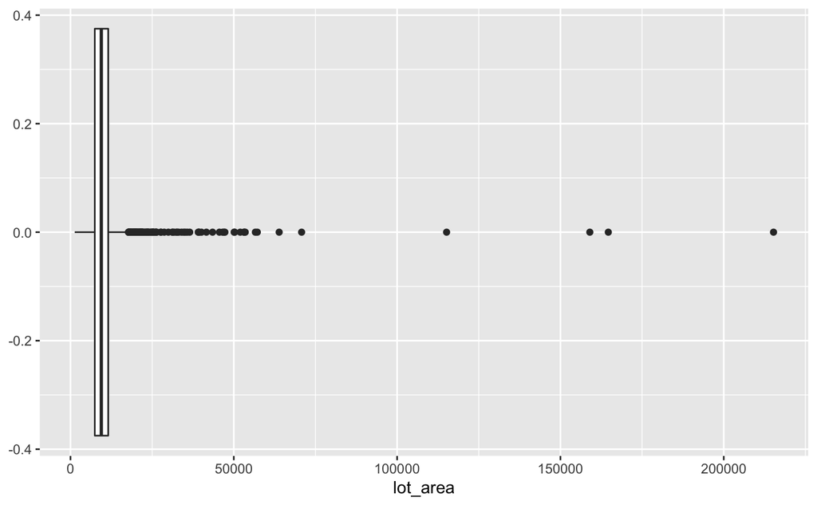

The distribution here almost looks normal to begin with, the majority of lot_area values are less than 25000, but it is skewed right by a relatively small amount of values much greater than this. It may look more normal without the outliers

## Task 3.

Compute and visualise a bootstrap sampling distribution for the mean(lot_area) of the sold houses.

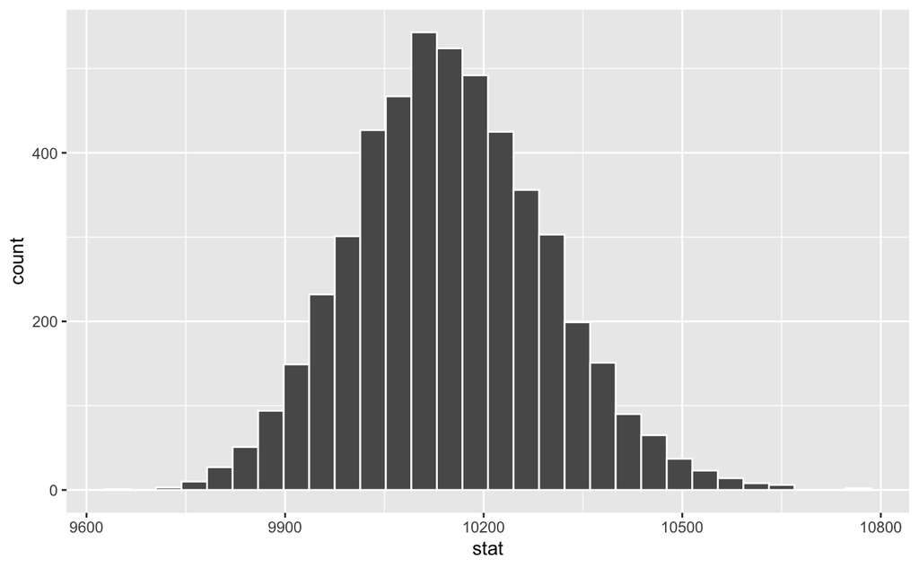

```r
# plot sampling distribution
bootstrap_lot_area %>%
  ggplot() +
  aes(x = stat) +
  geom_histogram(col = "white")
```

This distribution looks much better.

## Task 4.

Use your bootstrap distribution to calculate a 95% CI for mean(lot_area), and visualise it on the distribution

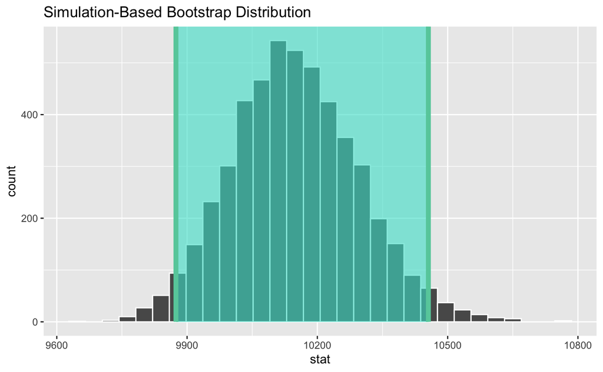

## Task 5.

You would like to know the mean(lot_area) of the sold houses with higher confidence. Calculate the 99% CI for this variable (you can re-use your bootstrap distribution from above). Is it narrower or broader than the 95% CI? Does that make sense?

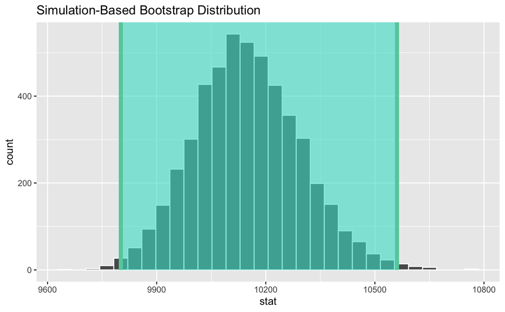

The 99% CI is slightly wider than the 95% CI. This makes sense as we are increasing the level of confidence in the interval, therefore including more mean values from our sampling distribution.

## Task 6.

Calculate the point estimate of the mean(lot_area)

| mean_lot_area |
| --- |
| 10149.5 |

# Extension

## Task 1.

Calculate a point estimate and 95% CI for the proportion of houses in the data built before 1920. Does the number of reps you use matter? [Investigate reps from 200 up to 50000, memory of your laptop permitting].

| built_before_1920 | count |
| --- | --- |
| FALSE | 2754 |
| TRUE | 176 |

```r
for (i in rep) {
bootstrap_year_built <- ames_before_1920 %>%
  specify(response = built_before_1920, success = "TRUE") %>%
  generate(reps = rep, type = "bootstrap") %>%
  calculate(stat = "prop")

# calculate 95% CI
ci_value <- bootstrap_year_built %>%
  get_ci(level = 0.95, type = "percentile")

# create summary
summary_values <- bootstrap_year_built %>%
  summarise(point_est = mean(stat)) %>%
  bind_cols(ci_value) %>%
  mutate(reps = rep)

summary_bootstrap <- bind_rows(summary_values)
}
```

```
Error in integer(n) : invalid 'length' argument
```

| point_est | lower_ci | upper_ci |
| --- | --- | --- |
| 0.05990444 | 0.0518686 | 0.06826792 |

| point_est | lower_ci | upper_ci |
| --- | --- | --- |
| 0.05976758 | 0.05153584 | 0.06791809 |

| point_est | lower_ci | upper_ci |
| --- | --- | --- |
| 0.06002765 | 0.05153584 | 0.06894198 |

| point_est | lower_ci | upper_ci |
| --- | --- | --- |
| 0.06005062 | 0.05153584 | 0.06894198 |

[output not shown]

200 reps: 0.05990444 0.0518686 0.06826792  
1000 reps: 0.05976758 0.05153584 0.06791809 10000 reps: 0.06002765 0.05153584 0.06894198  
50000 reps: 0.06005062 0.05153584 0.06894198

The amount of reps does not seem to make a signicant difference on the point estimate and CI on a the proportion.